# Nonlinear Methods: Fitting Classification Trees

## Regression/Classification Trees

Tree based method:

- Split up predictor space into regions, different predictions for each region
- Classification tree if goal is to classify (predict) group membership
  - For a given region, usually use most prevalent class as prediction
- Regression tree if goal is to predict a continuous response
  - For a given region, usually use mean of observations as prediction

## What About Fitting Classification Trees?

- Generally the same idea except
  - Residual sum of squares not good for splits
  - Usually Gini index or entropy/deviance used
  - For a binary response, within a given node (p = P(correct classification))

  \[Gini: 2p(1-p)\]

  \[Deviance: -2plog(p)-2(1-p)log(1-p)\]
  - Both will be small if p is near 0 or 1 (i.e. node classifies well)
  - For all possible splits, minimize this (weighted appropriately for node size)

## Classification Tree

Look at fit using "gini"

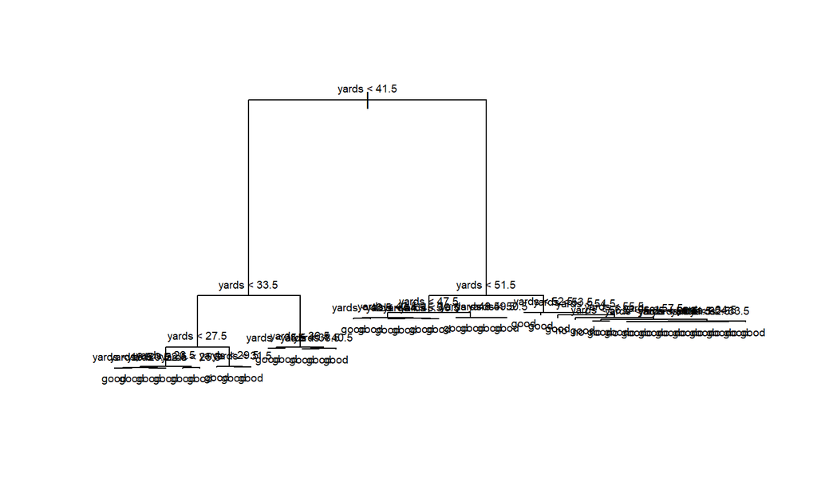

```r
giniFit <- tree(outcome ~ yards, data = FGData, split = "gini") #huge tree!
plot(giniFit) #Probably needs to be pruned
text(giniFit, pretty = 0, cex = 0.6)
```

## Visual (Gini = (# in Class)*2p(1-p))

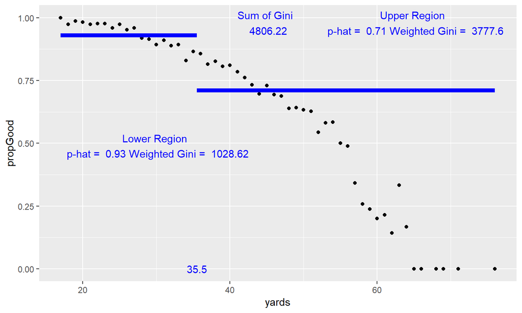

## Visual (Gini = (# in Class)*2p(1-p))

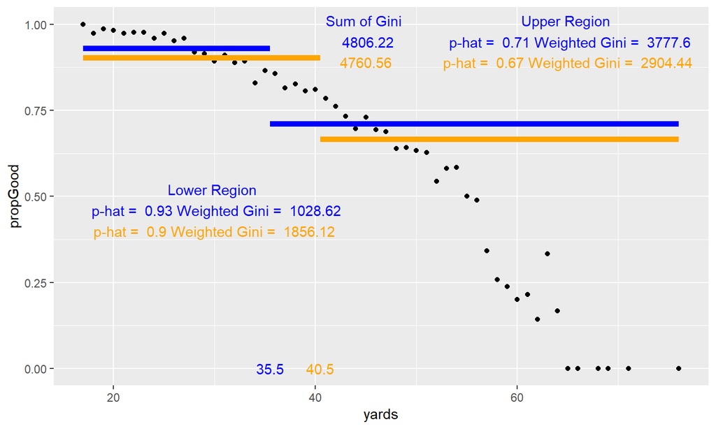

## Visual (Gini = (# in Class)*2p(1-p))

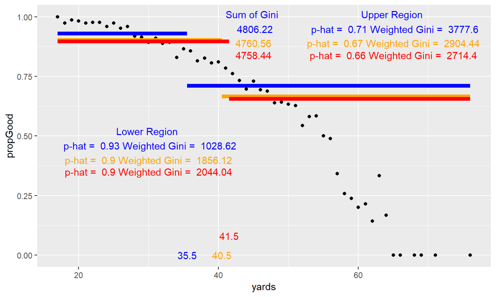

## Visual (Gini = (# in Class)*2p(1-p))

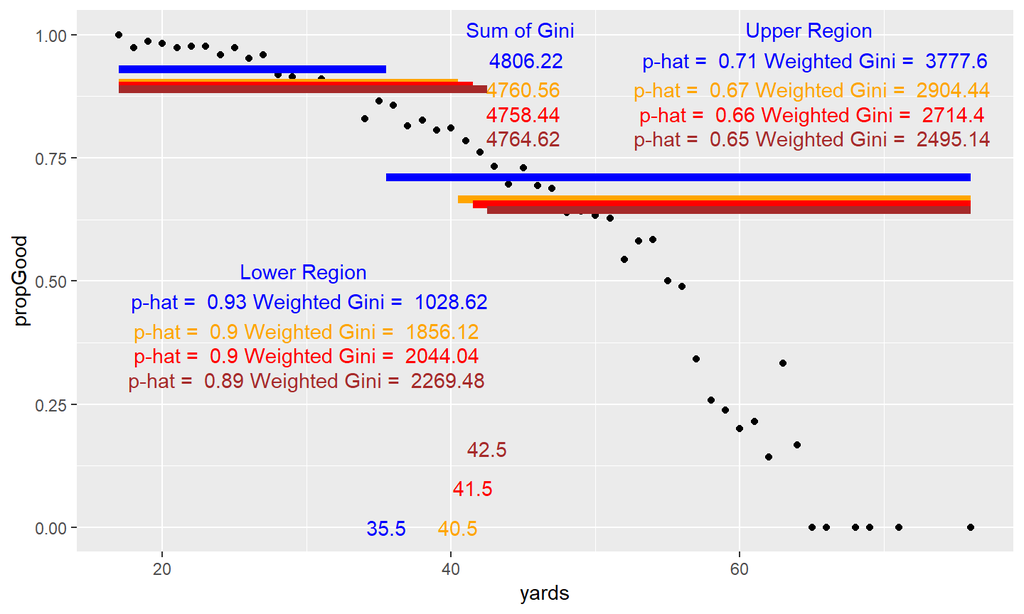

## Fitting Classification Trees

As with regression trees

- Once that split is chosen, the same process is used to create the second split
- Generally grow a `large' tree (many nodes)
- Tree then usually pruned back using *classification error rate*
  - Done to not overfit data
  - Prune back increases bias but decreases variance, hopefully improving prediction
- Generally, can choose number of nodes using cross-validation and compare against other models using test set prediction error

## Classification Trees Example

- Consider diamonds data set, predicting `cut`
- Fit full classification tree

```r
fullFit <- tree(cut ~ ., data = diamondsTrain)
summary(fullFit)
```

```
##
## Classification tree:
## tree(formula = cut ~ ., data = diamondsTrain)
## Variables actually used in tree construction:
## [1] "table" "depth"
## Number of terminal nodes:  7
## Residual mean deviance:  1.628 = 70240 / 43140
## Misclassification error rate: 0.3219 = 13889 / 43152
```

## Classification Trees Example

Fit pruned classification tree (using cost-complexity pruning)

`$dev` gives cross-validation rate (use minimum/most parsimonious)

```r
#uses misclassification when pruning
pruneFit <- cv.tree(fullFit, FUN = prune.misclass)
pruneFit
```

```
## $size
## [1] 7 6 5 4 3 2 1
##
## $dev
## [1] 13890 13890 14742 14742 15850 17202 25917
##
## $k
## [1] -Inf    0  411  441 1108 1352 8716
##
## $method
## [1] "misclass"
##
## attr(,"class")
## [1] "prune"         "tree.sequence"
```

## Visual of How CV Error Changes w/# of Nodes

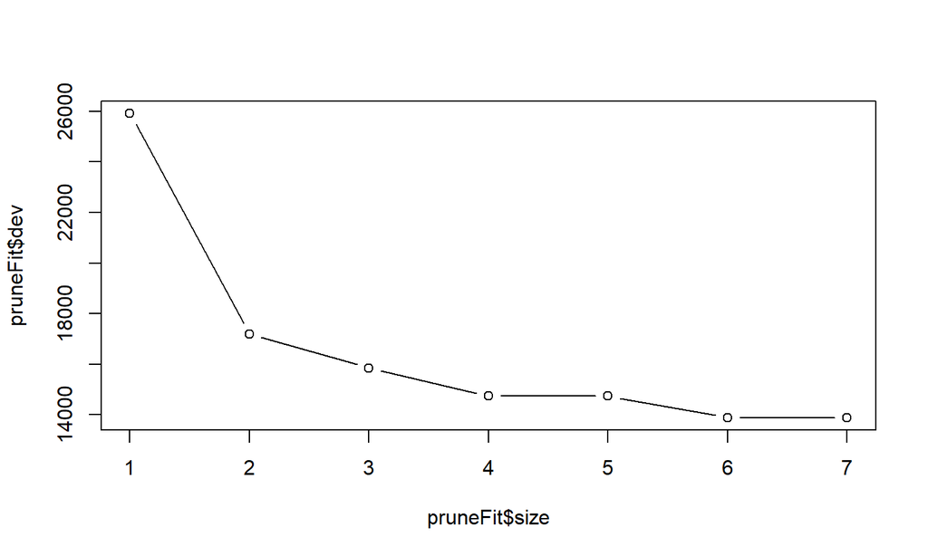

```r
plot(pruneFit$size ,pruneFit$dev ,type="b")
```

## Check Test Error

```r
pruneFitFinal <- prune.misclass(fullFit, best = 4)
#choosing 4 to have some differences

fullPred <- predict(fullFit, dplyr::select(diamondsTest, -"cut"), type = "class")

prunePred <- predict(pruneFitFinal, dplyr::select(diamondsTest, -"cut"), type = "class")
```

## Check Test Error

```r
fullTbl <- table(data.frame(fullPred, diamondsTest[, "cut"]))
fullTbl
```

```
##            cut
## fullPred    Fair Good Very Good Premium Ideal
##   Fair       235   37         4       0     2
##   Good         7  607       502       0    18
##   Very Good    0    0         0       0     0
##   Premium     75  310      1191    2404   227
##   Ideal        8   28       713     351  4069
```

```r
sum(diag(fullTbl)/sum(fullTbl))
```

```
## [1] 0.6780682
```

## Check Test Error

```r
pruneTbl <- table(data.frame(prunePred, diamondsTest[, "cut"]))
pruneTbl
```

```
##            cut
## prunePred   Fair Good Very Good Premium Ideal
##   Fair         0    0         0       0     0
##   Good       242  644       506       0    20
##   Very Good    0    0         0       0     0
##   Premium     75  310      1191    2404   227
##   Ideal        8   28       713     351  4069
```

```r
sum(diag(pruneTbl)/sum(pruneTbl))
```

```
## [1] 0.6597145
```

## Pros and Cons of Trees

Pros:

- Simple to understand and easy to interpret output
- Predictors don't need to be scaled
- No statistical assumptions necessary
- Built in variable selection

Cons:

- Small changes in data can vastly change tree
- Greedy algorithm necessary (no optimal algorithm)
- Need to prune (usually)

Random Forests, boosting, and bagging are three methods that average across trees. Lose interpetability but gain in prediction!

## Other Packages Used

- `rpart` with `rpart.plot`
- `party`
- `randomForest`

Next up:

- Improving prediction using ensembles (averaging across models)